# project1_p2

```r
data$class <- with( data
                    , ifelse(shares < 800 ,1
                            ,ifelse(shares >= 800 & shares < 1000 ,2
                                     ,ifelse(shares >= 1000 & shares < 2000 ,3
                                             ,ifelse(shares >= 2000 & shares < 2000000 ,4 ,5)))))
```

In preprocessing we use mutual information value. It is said that it can also choose variables that are highly correlated, which is unwanted, but since we removed those earlier, there is no such problem now. Mutual information is diffrenet from correlation, because correlation finds variables that hold the same information and mutual information is about finding variables that hold information on the same model as the other variable.

## Classification

We have used 2 Type of resampling : K-fold and Bootstrap Sampling.

**K-fold** :Here the samples are randomly partitioned into k sets (called folds) of roughly equal size. A model is fit using all the samples except the first subset. Then, the prediction error of the fitted model is calculated using the first held-out samples. The same operation is repeated for each fold and the model’s performance is calculated by averaging the errors across the different test sets. kk is usually fixed at 5 or 10 . Cross-validation provides an estimate of the test error for each model6. Cross-validation is one of the most widely-used method for model selection, and for choosing tuning parameter values.

The **bootstrap** is a simulation-based procedure for estimating and validating distributions. It is useful when: The theoretical distribution of a statistic is complicated or unknown. The sample size is insufficient for straightforward statistical inference. Inshort, we use bootstrap to derive an empirical distribution and confidence intervals for a sample median, which lacks a theoretical distribution.

### Random forest

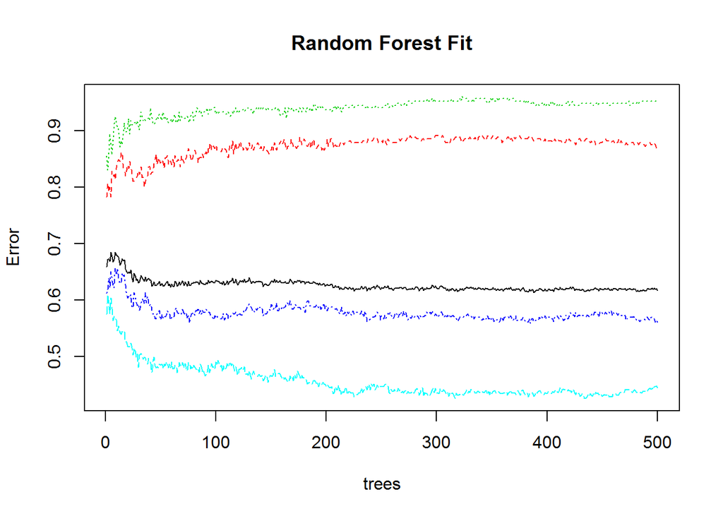

```r
random_forest1 <- randomForest(class ~ ., data = Online_train, importance = TRUE, na.action = na.omit)
predictions <- predict(random_forest1, Online_test)

plot(random_forest1, main="Random Forest Fit")
```

```r
confusionMatrix <- confusionMatrix(predictions, Online_test$class)
confusionMatrix
```

```
## Confusion Matrix and Statistics
##
##           Reference
## Prediction   1   2   3   4
##          1  49  20  30  25
##          2  14  23  21   9
##          3 146 119 372 261
##          4  97  95 278 425
##
## Overall Statistics
##
##                Accuracy : 0.438
##                  95% CI : (0.416, 0.4602)
##     No Information Rate : 0.3629
##     P-Value [Acc > NIR] : 3.709e-12
##
##                   Kappa : 0.1515
##  Mcnemar's Test P-Value : < 2.2e-16
##
## Statistics by Class:
##
##                      Class: 1 Class: 2 Class: 3 Class: 4
## Sensitivity            0.1601  0.08949   0.5307   0.5903
## Specificity            0.9553  0.97452   0.5900   0.6282
## Pos Pred Value         0.3952  0.34328   0.4143   0.4749
## Neg Pred Value         0.8618  0.87793   0.6971   0.7291
## Prevalence             0.1542  0.12954   0.3533   0.3629
## Detection Rate         0.0247  0.01159   0.1875   0.2142
## Detection Prevalence   0.0625  0.03377   0.4526   0.4511
## Balanced Accuracy      0.5577  0.53201   0.5603   0.6092
```

```r
tab <- table(true = Online_test$class, predicted = predictions)
rfAccuracy = sum(diag(tab)) / sum(tab)
rfAccuracy
```

```
## [1] 0.438004
```

#### random forest : K-fold cross validation

```r
train_control <- trainControl(method="repeatedcv", number=10, repeats=3)
random_forest2 <- train(class ~ ., data = Online_train, trControl=train_control, method="rf")
predictions <- predict(random_forest2, Online_test)
confusionMatrix <- confusionMatrix(predictions, Online_test$class)
confusionMatrix
```

```
## Confusion Matrix and Statistics
##
##           Reference
## Prediction   1   2   3   4
##          1  32  13  10  14
##          2   3  15   2   1
##          3 181 143 406 270
##          4  90  86 283 435
##
## Overall Statistics
##
##                Accuracy : 0.4476
##                  95% CI : (0.4255, 0.4698)
##     No Information Rate : 0.3629
##     P-Value [Acc > NIR] : 6.024e-15
##
##                   Kappa : 0.1523
##  Mcnemar's Test P-Value : < 2.2e-16
##
## Statistics by Class:
##
##                      Class: 1 Class: 2 Class: 3 Class: 4
## Sensitivity           0.10458  0.05837   0.5792   0.6042
## Specificity           0.97795  0.99653   0.5370   0.6369
## Pos Pred Value        0.46377  0.71429   0.4060   0.4866
## Neg Pred Value        0.85692  0.87672   0.7002   0.7385
## Prevalence            0.15423  0.12954   0.3533   0.3629
## Detection Rate        0.01613  0.00756   0.2046   0.2193
## Detection Prevalence  0.03478  0.01058   0.5040   0.4506
## Balanced Accuracy     0.54126  0.52745   0.5581   0.6205
```

```r
tab <- table(true = Online_test$class, predicted = predictions)
rfKFoldAccuracy = sum(diag(tab)) / sum(tab)
rfKFoldAccuracy
```

```
## [1] 0.4475806
```

#### random forest : Bootstrap

```r
train_control <- trainControl(method="boot", number=10)
random_forest3 <- train(class ~ ., data = Online_train, trControl=train_control, method="rf")
predictions <- predict(random_forest3, Online_test)
confusionMatrix <- confusionMatrix(predictions, Online_test$class)
confusionMatrix
```

```
## Confusion Matrix and Statistics
##
##           Reference
## Prediction   1   2   3   4
##          1  33  13  12  12
##          2   4  14   2   1
##          3 168 135 399 260
##          4 101  95 288 447
##
## Overall Statistics
##
##                Accuracy : 0.4501
##                  95% CI : (0.428, 0.4723)
##     No Information Rate : 0.3629
##     P-Value [Acc > NIR] : 9.854e-16
##
##                   Kappa : 0.156
##  Mcnemar's Test P-Value : < 2.2e-16
##
## Statistics by Class:
##
##                      Class: 1 Class: 2 Class: 3 Class: 4
## Sensitivity           0.10784 0.054475   0.5692   0.6208
## Specificity           0.97795 0.995947   0.5612   0.6171
## Pos Pred Value        0.47143 0.666667   0.4148   0.4801
## Neg Pred Value        0.85737 0.876210   0.7045   0.7407
## Prevalence            0.15423 0.129536   0.3533   0.3629
## Detection Rate        0.01663 0.007056   0.2011   0.2253
## Detection Prevalence  0.03528 0.010585   0.4849   0.4693
## Balanced Accuracy     0.54290 0.525211   0.5652   0.6190
```

```r
tab <- table(true = Online_test$class, predicted = predictions)
rfBootstrapAccuracy = sum(diag(tab)) / sum(tab)
rfBootstrapAccuracy
```

```
## [1] 0.4501008
```

### Decision tree

#### ctree

```r
decision_tree1 <- ctree(class ~ ., data = Online_train)
predictions <- predict(decision_tree1, Online_test )
confusionMatrix <- confusionMatrix(predictions, Online_test$class)
confusionMatrix
```

```
## Confusion Matrix and Statistics
##
##           Reference
## Prediction   1   2   3   4
##          1  72  60  96  73
##          2   0   0   0   0
##          3 142 108 236 162
##          4  92  89 369 485
##
## Overall Statistics
##
##                Accuracy : 0.3997
##                  95% CI : (0.3781, 0.4216)
##     No Information Rate : 0.3629
##     P-Value [Acc > NIR] : 0.0003833
##
##                   Kappa : 0.1065
##  Mcnemar's Test P-Value : < 2.2e-16
##
## Statistics by Class:
##
##                      Class: 1 Class: 2 Class: 3 Class: 4
## Sensitivity           0.23529   0.0000   0.3367   0.6736
## Specificity           0.86353   1.0000   0.6789   0.5649
## Pos Pred Value        0.23920      NaN   0.3642   0.4686
## Neg Pred Value        0.86096   0.8705   0.6519   0.7524
## Prevalence            0.15423   0.1295   0.3533   0.3629
## Detection Rate        0.03629   0.0000   0.1190   0.2445
## Detection Prevalence  0.15171   0.0000   0.3266   0.5217
## Balanced Accuracy     0.54941   0.5000   0.5078   0.6192
```

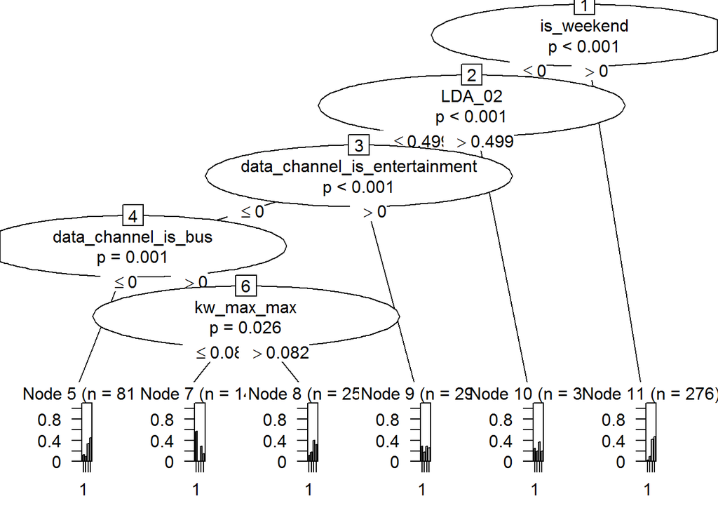

```r
plot(decision_tree1)
```

```r
tab <- table(true = Online_test$class, predicted = predictions)
treeAccuracy = sum(diag(tab)) / sum(tab)
treeAccuracy
```

```
## [1] 0.3996976
```

#### rtree:Recursive partitioning for classification,regression and survival trees. multiclass problem in rpart

```r
rtree1 <- rpart(class ~ ., data = Online_train, method="class")
predictions <- predict(rtree1, Online_test)
```

#### ctree: K-fold cross validation

```r
train_control <- trainControl(method="cv", number=10)
decision_tree2 <- train(class ~ ., data = Online_train, trControl=train_control, method="ctree")
predictions <- predict(decision_tree2, Online_test)
confusionMatrix <- confusionMatrix(predictions, Online_test$class)
confusionMatrix
```

```
## Confusion Matrix and Statistics
##
##           Reference
## Prediction   1   2   3   4
##          1  69  58  87  64
##          2   0   0   0   0
##          3 145 110 245 171
##          4  92  89 369 485
##
## Overall Statistics
##
##                Accuracy : 0.4027
##                  95% CI : (0.381, 0.4247)
##     No Information Rate : 0.3629
##     P-Value [Acc > NIR] : 0.0001358
##
##                   Kappa : 0.108
##  Mcnemar's Test P-Value : < 2.2e-16
##
## Statistics by Class:
##
##                      Class: 1 Class: 2 Class: 3 Class: 4
## Sensitivity           0.22549   0.0000   0.3495   0.6736
## Specificity           0.87545   1.0000   0.6680   0.5649
## Pos Pred Value        0.24820      NaN   0.3651   0.4686
## Neg Pred Value        0.86108   0.8705   0.6527   0.7524
## Prevalence            0.15423   0.1295   0.3533   0.3629
## Detection Rate        0.03478   0.0000   0.1235   0.2445
## Detection Prevalence  0.14012   0.0000   0.3382   0.5217
## Balanced Accuracy     0.55047   0.5000   0.5087   0.6192
```

```r
tab <- table(true = Online_test$class, predicted = predictions)
treeKFoldAccuracy = sum(diag(tab)) / sum(tab)
treeKFoldAccuracy
```

```
## [1] 0.4027218
```

#### rpart: K-fold cross validation

```r
rtree2 <- train(class ~ ., data = Online_train, trControl=train_control, method="rpart")
predictions <- predict(rtree2, Online_test)
confusionMatrix <- confusionMatrix(predictions, Online_test$class)
confusionMatrix
```

```
## Confusion Matrix and Statistics
##
##           Reference
## Prediction   1   2   3   4
##          1   0   0   0   0
##          2   0   0   0   0
##          3 181 142 328 255
##          4 125 115 373 465
##
## Overall Statistics
##
##                Accuracy : 0.3997
##                  95% CI : (0.3781, 0.4216)
##     No Information Rate : 0.3629
##     P-Value [Acc > NIR] : 0.0003833
##
##                   Kappa : 0.0642
##  Mcnemar's Test P-Value : NA
##
## Statistics by Class:
##
##                      Class: 1 Class: 2 Class: 3 Class: 4
## Sensitivity            0.0000   0.0000   0.4679   0.6458
## Specificity            1.0000   1.0000   0.5495   0.5150
## Pos Pred Value            NaN      NaN   0.3620   0.4314
## Neg Pred Value         0.8458   0.8705   0.6540   0.7185
## Prevalence             0.1542   0.1295   0.3533   0.3629
## Detection Rate         0.0000   0.0000   0.1653   0.2344
## Detection Prevalence   0.0000   0.0000   0.4567   0.5433
## Balanced Accuracy      0.5000   0.5000   0.5087   0.5804
```

```r
tab <- table(true = Online_test$class, predicted = predictions)
treeRpartKFoldAccuracy = sum(diag(tab)) / sum(tab)
treeRpartKFoldAccuracy
```

```
## [1] 0.3996976
```

#### Bootstrap

```r
train_control <- trainControl(method="boot", number=10)
# ctree
decision_tree3 <- train(class ~ ., data = Online_train, trControl=train_control, method="ctree")
predictions <- predict(decision_tree3, Online_test)
confusionMatrix <- confusionMatrix(predictions, Online_test$class)
confusionMatrix
```

```
## Confusion Matrix and Statistics
##
##           Reference
## Prediction   1   2   3   4
##          1  69  58  87  64
##          2   0   0   0   0
##          3 145 110 245 171
##          4  92  89 369 485
##
## Overall Statistics
##
##                Accuracy : 0.4027
##                  95% CI : (0.381, 0.4247)
##     No Information Rate : 0.3629
##     P-Value [Acc > NIR] : 0.0001358
##
##                   Kappa : 0.108
##  Mcnemar's Test P-Value : < 2.2e-16
##
## Statistics by Class:
##
##                      Class: 1 Class: 2 Class: 3 Class: 4
## Sensitivity           0.22549   0.0000   0.3495   0.6736
## Specificity           0.87545   1.0000   0.6680   0.5649
## Pos Pred Value        0.24820      NaN   0.3651   0.4686
## Neg Pred Value        0.86108   0.8705   0.6527   0.7524
## Prevalence            0.15423   0.1295   0.3533   0.3629
## Detection Rate        0.03478   0.0000   0.1235   0.2445
## Detection Prevalence  0.14012   0.0000   0.3382   0.5217
## Balanced Accuracy     0.55047   0.5000   0.5087   0.6192
```

```r
tab <- table(true = Online_test$class, predicted = predictions)
treeBootstrapAccuracy = sum(diag(tab)) / sum(tab)
treeBootstrapAccuracy
```

```
## [1] 0.4027218
```

```r
# rtree
rtree3 <- train(class ~ ., data = Online_train, trControl=train_control, method="rpart")
predictions <- predict(rtree3, Online_test)
confusionMatrix <- confusionMatrix(predictions, Online_test$class)
confusionMatrix
```

```
## Confusion Matrix and Statistics
##
##           Reference
## Prediction   1   2   3   4
##          1   0   0   0   0
##          2   0   0   0   0
##          3 181 142 328 255
##          4 125 115 373 465
##
## Overall Statistics
##
##                Accuracy : 0.3997
##                  95% CI : (0.3781, 0.4216)
##     No Information Rate : 0.3629
##     P-Value [Acc > NIR] : 0.0003833
##
##                   Kappa : 0.0642
##  Mcnemar's Test P-Value : NA
##
## Statistics by Class:
##
##                      Class: 1 Class: 2 Class: 3 Class: 4
## Sensitivity            0.0000   0.0000   0.4679   0.6458
## Specificity            1.0000   1.0000   0.5495   0.5150
## Pos Pred Value            NaN      NaN   0.3620   0.4314
## Neg Pred Value         0.8458   0.8705   0.6540   0.7185
## Prevalence             0.1542   0.1295   0.3533   0.3629
## Detection Rate         0.0000   0.0000   0.1653   0.2344
## Detection Prevalence   0.0000   0.0000   0.4567   0.5433
## Balanced Accuracy      0.5000   0.5000   0.5087   0.5804
```

```r
tab <- table(true = Online_test$class, predicted = predictions)
treeRpartBootstrapAccuracy = sum(diag(tab)) / sum(tab)
treeRpartBootstrapAccuracy
```

```
## [1] 0.3996976
```

```r
###knn : K Nearest Neighbour
knnFit1 <- knn3(class ~ ., data = Online_train, k=38) #we computed OptimalK in Phase1 & it gave hightest performance for 38
predictions <- predict(knnFit1, Online_test )
##knn : K-fold cross validation
tlength = 20
train_control <- trainControl(method="cv", number=10)
knnfit2 <- train(class ~ ., data = Online_train, trControl=train_control, method="knn", tuneLength = tlength)
klist <-knnfit2$bestTune[[1]]
predictions <- predict(knnfit2, Online_test )
confusionMatrix(predictions, Online_test$class)
```

```
## Confusion Matrix and Statistics
##
##           Reference
## Prediction   1   2   3   4
##          1  54  37  63  49
##          2   0   0   1   2
##          3 168 144 370 305
##          4  84  76 267 364
##
## Overall Statistics
##
##                Accuracy : 0.3972
##                  95% CI : (0.3756, 0.4191)
##     No Information Rate : 0.3629
##     P-Value [Acc > NIR] : 0.0008621
##
##                   Kappa : 0.0915
##  Mcnemar's Test P-Value : < 2.2e-16
##
## Statistics by Class:
##
##                      Class: 1 Class: 2 Class: 3 Class: 4
## Sensitivity           0.17647 0.000000   0.5278   0.5056
## Specificity           0.91120 0.998263   0.5191   0.6622
## Pos Pred Value        0.26601 0.000000   0.3749   0.4602
## Neg Pred Value        0.85851 0.870268   0.6680   0.7016
## Prevalence            0.15423 0.129536   0.3533   0.3629
## Detection Rate        0.02722 0.000000   0.1865   0.1835
## Detection Prevalence  0.10232 0.001512   0.4975   0.3987
## Balanced Accuracy     0.54384 0.499131   0.5235   0.5839
```

```r
confusionMatrix
```

```
## Confusion Matrix and Statistics
##
##           Reference
## Prediction   1   2   3   4
##          1   0   0   0   0
##          2   0   0   0   0
##          3 181 142 328 255
##          4 125 115 373 465
##
## Overall Statistics
##
##                Accuracy : 0.3997
##                  95% CI : (0.3781, 0.4216)
##     No Information Rate : 0.3629
##     P-Value [Acc > NIR] : 0.0003833
##
##                   Kappa : 0.0642
##  Mcnemar's Test P-Value : NA
##
## Statistics by Class:
##
##                      Class: 1 Class: 2 Class: 3 Class: 4
## Sensitivity            0.0000   0.0000   0.4679   0.6458
## Specificity            1.0000   1.0000   0.5495   0.5150
## Pos Pred Value            NaN      NaN   0.3620   0.4314
## Neg Pred Value         0.8458   0.8705   0.6540   0.7185
## Prevalence             0.1542   0.1295   0.3533   0.3629
## Detection Rate         0.0000   0.0000   0.1653   0.2344
## Detection Prevalence   0.0000   0.0000   0.4567   0.5433
## Balanced Accuracy      0.5000   0.5000   0.5087   0.5804
```

```r
cvk = knnfit2$bestTune[[1]]

tab <- table(true = Online_test$class, predicted = predictions)
knnKFoldAccuracy = sum(diag(tab)) / sum(tab)
knnKFoldAccuracy
```

```
## [1] 0.3971774
```

```r
#knn : Bootstraps
train_control <- trainControl(method="boot", number=10)
knnfit3 <- train(class ~ ., data = Online_train, trControl=train_control, method="knn", tuneLength = 20)
predictions <- predict(knnfit3, Online_test)
confusionMatrix(predictions, Online_test$class)
```

```
## Confusion Matrix and Statistics
##
##           Reference
## Prediction   1   2   3   4
##          1  57  43  75  43
##          2   4   4   7   3
##          3 160 134 352 275
##          4  85  76 267 399
##
## Overall Statistics
##
##                Accuracy : 0.4093
##                  95% CI : (0.3875, 0.4313)
##     No Information Rate : 0.3629
##     P-Value [Acc > NIR] : 1.122e-05
##
##                   Kappa : 0.1138
##  Mcnemar's Test P-Value : < 2.2e-16
##
## Statistics by Class:
##
##                      Class: 1 Class: 2 Class: 3 Class: 4
## Sensitivity           0.18627 0.015564   0.5021   0.5542
## Specificity           0.90405 0.991893   0.5565   0.6614
## Pos Pred Value        0.26147 0.222222   0.3822   0.4825
## Neg Pred Value        0.85900 0.871312   0.6717   0.7226
## Prevalence            0.15423 0.129536   0.3533   0.3629
## Detection Rate        0.02873 0.002016   0.1774   0.2011
## Detection Prevalence  0.10988 0.009073   0.4642   0.4168
## Balanced Accuracy     0.54516 0.503729   0.5293   0.6078
```

```r
confusionMatrix
```

```
## Confusion Matrix and Statistics
##
##           Reference
## Prediction   1   2   3   4
##          1   0   0   0   0
##          2   0   0   0   0
##          3 181 142 328 255
##          4 125 115 373 465
##
## Overall Statistics
##
##                Accuracy : 0.3997
##                  95% CI : (0.3781, 0.4216)
##     No Information Rate : 0.3629
##     P-Value [Acc > NIR] : 0.0003833
##
##                   Kappa : 0.0642
##  Mcnemar's Test P-Value : NA
##
## Statistics by Class:
##
##                      Class: 1 Class: 2 Class: 3 Class: 4
## Sensitivity            0.0000   0.0000   0.4679   0.6458
## Specificity            1.0000   1.0000   0.5495   0.5150
## Pos Pred Value            NaN      NaN   0.3620   0.4314
## Neg Pred Value         0.8458   0.8705   0.6540   0.7185
## Prevalence             0.1542   0.1295   0.3533   0.3629
## Detection Rate         0.0000   0.0000   0.1653   0.2344
## Detection Prevalence   0.0000   0.0000   0.4567   0.5433
## Balanced Accuracy      0.5000   0.5000   0.5087   0.5804
```

```r
bk = knnfit3$bestTune[[1]]

tab <- table(true = Online_test$class, predicted = predictions)
knnBootstrapAccuracy = sum(diag(tab)) / sum(tab)
knnBootstrapAccuracy
```

```
## [1] 0.4092742
```

### SVM : Support Vector Machines

# Support Vector Machine (SVM) is a discriminative classifier formally defined by a separating hyperplane. In other words, given labeled training data (supervised learning), the algorithm outputs an optimal hyperplane which categorizes test data

```r
options(warn=-1)
svm1 <- svm(class ~ ., data = Online_train, kernel='linear', cost=10, scale=FALSE, probability = TRUE)
predictions <- predict(svm1, Online_test )

confusionMatrix <- confusionMatrix(predictions, Online_test$class)
confusionMatrix
```

```
## Confusion Matrix and Statistics
##
##           Reference
## Prediction   1   2   3   4
##          1  25  20  39  24
##          2   0   0   0   0
##          3 197 154 354 272
##          4  84  83 308 424
##
## Overall Statistics
##
##                Accuracy : 0.4047
##                  95% CI : (0.383, 0.4267)
##     No Information Rate : 0.3629
##     P-Value [Acc > NIR] : 6.533e-05
##
##                   Kappa : 0.0887
##  Mcnemar's Test P-Value : < 2.2e-16
##
## Statistics by Class:
##
##                      Class: 1 Class: 2 Class: 3 Class: 4
## Sensitivity           0.08170   0.0000   0.5050   0.5889
## Specificity           0.95054   1.0000   0.5144   0.6242
## Pos Pred Value        0.23148      NaN   0.3623   0.4716
## Neg Pred Value        0.85021   0.8705   0.6554   0.7272
## Prevalence            0.15423   0.1295   0.3533   0.3629
## Detection Rate        0.01260   0.0000   0.1784   0.2137
## Detection Prevalence  0.05444   0.0000   0.4924   0.4531
## Balanced Accuracy     0.51612   0.5000   0.5097   0.6065
```

```r
tab <- table(true = Online_test$class, predicted = predictions)
svmAccuracy = sum(diag(tab)) / sum(tab)
svmAccuracy
```

```
## [1] 0.4047379
```

#### SVM: K-fold cross validation

```r
train_control <- trainControl(method="cv", number=10)
svm2 <- train(class ~ ., data = Online_train, trControl=train_control, method="svmLinear") #Support Vector Machines with Linear Kernel
predictions <- predict(svm2, Online_test )
confusionMatrix <- confusionMatrix(predictions, Online_test$class)
confusionMatrix
```

```
## Confusion Matrix and Statistics
##
##           Reference
## Prediction   1   2   3   4
##          1  17  12  26  16
##          2   0   0   0   0
##          3 200 163 364 277
##          4  89  82 311 427
##
## Overall Statistics
##
##                Accuracy : 0.4073
##                  95% CI : (0.3855, 0.4293)
##     No Information Rate : 0.3629
##     P-Value [Acc > NIR] : 2.504e-05
##
##                   Kappa : 0.0873
##  Mcnemar's Test P-Value : < 2.2e-16
##
## Statistics by Class:
##
##                      Class: 1 Class: 2 Class: 3 Class: 4
## Sensitivity          0.055556   0.0000   0.5193   0.5931
## Specificity          0.967819   1.0000   0.5012   0.6187
## Pos Pred Value       0.239437      NaN   0.3625   0.4697
## Neg Pred Value       0.848928   0.8705   0.6561   0.7274
## Prevalence           0.154234   0.1295   0.3533   0.3629
## Detection Rate       0.008569   0.0000   0.1835   0.2152
## Detection Prevalence 0.035786   0.0000   0.5060   0.4582
## Balanced Accuracy    0.511687   0.5000   0.5102   0.6059
```

```r
tab <- table(true = Online_test$class, predicted = predictions)
svmKFoldAccuracy = sum(diag(tab)) / sum(tab)
svmKFoldAccuracy
```

```
## [1] 0.4072581
```

#### SVM: Bootstrap

```r
train_control <- trainControl(method="boot", number=10)
svm3 <- train(class ~ ., data = Online_train, trControl=train_control, method="svmLinear")
predictions <- predict(svm3, Online_test)
confusionMatrix <- confusionMatrix(predictions, Online_test$class)
confusionMatrix
```

```
## Confusion Matrix and Statistics
##
##           Reference
## Prediction   1   2   3   4
##          1  17  12  26  16
##          2   0   0   0   0
##          3 200 163 364 277
##          4  89  82 311 427
##
## Overall Statistics
##
##                Accuracy : 0.4073
##                  95% CI : (0.3855, 0.4293)
##     No Information Rate : 0.3629
##     P-Value [Acc > NIR] : 2.504e-05
##
##                   Kappa : 0.0873
##  Mcnemar's Test P-Value : < 2.2e-16
##
## Statistics by Class:
##
##                      Class: 1 Class: 2 Class: 3 Class: 4
## Sensitivity          0.055556   0.0000   0.5193   0.5931
## Specificity          0.967819   1.0000   0.5012   0.6187
## Pos Pred Value       0.239437      NaN   0.3625   0.4697
## Neg Pred Value       0.848928   0.8705   0.6561   0.7274
## Prevalence           0.154234   0.1295   0.3533   0.3629
## Detection Rate       0.008569   0.0000   0.1835   0.2152
## Detection Prevalence 0.035786   0.0000   0.5060   0.4582
## Balanced Accuracy    0.511687   0.5000   0.5102   0.6059
```

```r
tab <- table(true = Online_test$class, predicted = predictions)
svmBootstrapAccuracy = sum(diag(tab)) / sum(tab)
svmBootstrapAccuracy
```

```
## [1] 0.4072581
```

### Using *train Model by tag* Method

```r
control <- trainControl(method="repeatedcv", number=10, repeats=3) # set crossvalidation sampling method
```

### LDA:Linear Discriminant Analysis

```r
set.seed(7)
modelLda <- train(class ~ ., data = Online_train, method="lda", trControl=control)
tab <- table(true = Online_test$class, predicted = predict(modelLda, Online_test))
ldaAccuracy = sum(diag(tab)) / sum(tab)
ldaAccuracy
```

```
## [1] 0.4148185
```

### QDA: Quadratic Discriminant Analysis

```r
#set.seed(7)
#modelQda <- train(class ~ ., data = Online_train, method="qda", trControl=control)
#tab <- table(true = Online_test$class, predicted = predict(modelQda, Online_test))
#qdaAccuracy = sum(diag(tab)) / sum(tab)
#qdaAccuracy
```

### GBM :Stochastic Gradient Boosting

```r
set.seed(7)
modelGbm <- train(class ~ ., data = Online_train, method="gbm", trControl=control)
tab <- table(true = Online_test$class, predicted = predict(modelGbm, Online_test))
gbmAccuracy = sum(diag(tab)) / sum(tab)
gbmAccuracy
```

```
## [1] 0.421371
```

### Multinomial logistic regression

```r
modelMLR <- multinom(class ~ ., data = Online_train)
tab <- table(true = Online_test$class, predicted = predict(modelMLR, Online_test))
MLRAccuracy = sum(diag(tab)) / sum(tab)
MLRAccuracy
```

```
## [1] 0.4092742
```

## Summary

```r
accuracy <- matrix (c( rfAccuracy,rfKFoldAccuracy,rfBootstrapAccuracy,
                       treeAccuracy,
                       treeKFoldAccuracy,treeRpartKFoldAccuracy,
                       treeBootstrapAccuracy,treeRpartBootstrapAccuracy,
                       knnKFoldAccuracy,knnBootstrapAccuracy,
                       svmAccuracy,svmKFoldAccuracy,svmBootstrapAccuracy,
                       ldaAccuracy,
                       gbmAccuracy,
                       MLRAccuracy ), byrow=FALSE)
rownames(accuracy) <- c("Random forest","Random forest: K-fold","Random forest:Bootstrap",
                        "Decision tree",
                        "Decision tree K-Fold","Decision tree K-Fold rpart",
                        "Decision tree Bootstrap","Decision tree Bootstrap rpart",
                        "K-nearest neighbours K-Fold","K-nearest neighbours  Bootstrap",
                        "SVM","SVM K-Fold","SVM Bootstrap",
                        "LDA",
                        "GBM",
                        "multinomial logistic regression");
colnames(accuracy) <- c("Accuracy")
accuracy <- as.table(accuracy)
accuracy
```

```
##                                  Accuracy
## Random forest                   0.4380040
## Random forest: K-fold           0.4475806
## Random forest:Bootstrap         0.4501008
## Decision tree                   0.3996976
## Decision tree K-Fold            0.4027218
## Decision tree K-Fold rpart      0.3996976
## Decision tree Bootstrap         0.4027218
## Decision tree Bootstrap rpart   0.3996976
## K-nearest neighbours K-Fold     0.3971774
## K-nearest neighbours  Bootstrap 0.4092742
## SVM                             0.4047379
## SVM K-Fold                      0.4072581
## SVM Bootstrap                   0.4072581
## LDA                             0.4148185
## GBM                             0.4213710
## multinomial logistic regression 0.4092742
```

```r
#########-----------------results of all methods-----------
##collect resamples
#results <- resamples(list(
#  randomForest = random_forest1,
#                           randomForestKFold = random_forest2,
#                           randomForestBootstrap = random_forest3 ,
#                          tree=decision_tree1,
#                          treeKFold=decision_tree2,
#                          treeBootstrap=decision_tree3,
#                          knn=knnFit1,
#                          knnKFold=knnfit2,
#                          knnBootstrap= knnfit3,
#                          SVM=svm1,
#                          SVMKFold=svm2,
#                          SVMBootstrap=svm3,
#                          lda=modelLda,
#                          GBM=modelGbm,
#                          MLR= modelMLR))
##summarize the distributions
#summary(results)
```

[output not shown]